# Refreshment Workshop: Key Concepts in Probability and Statistics

María Katalina Leyva Diaz

2025-01-25

```r
library(tidyverse)
```

```r
library(ggplot2)
```

**1. Suppose the probability of a student passing a course is 0.7, and the probability of a passing a different course is 0.5. The probability of both courses is 0.4. Are these events independent? Justify the answer.**

**Solution:**

Given, $A = $ Passing a course.

**2. A box contains 5 red balls and 7 blue balls. Two balls are drawn at random without replacement. What is the probability that the second ball drawn is red, given that the first ball drawn is blue?**

**Solution:**

Given,

$A =$ 7 blue balls.

$B =$ 5 red balls.

There are 12 balls in the box. Since, it is without replacement, the probability of drawing a blue ball is $P_r(A) = \frac{7}{12}$ and the probability of drawing a red ball is $P_r(B) = \frac{5}{11}$. Hence, the probability that the second ball drawn is red, given that the first ball is blue, is:

$$P_r(B/A) = \frac{P_r(A \cap
B)}{P_r(A)}$$
$$P_r(B/A) = \frac{
\frac{5}{11} * \frac{7}{12}}{ \frac{7}{12} }$$
$$P_r(B/A) = \frac{5}{11}$$

**3. A fair coin is flipped 3 times. Given that at least one heads is observed, what is the probability that exactly two heads occur?**

**Solution:**

Given,

$A =$ Exactly two heads occur.

$B =$ At least one heads is observed.

Since, the possible outcomes are: $R = \{SHH, SHS, HSH, HSS, SSH, HHS, HHH, SSS \}$. So, the probability of event A is $P(A) = \frac {3}{8}$ and probability of event B is $P(B) = \frac{7}{8}$.

Furthermore, in the process of taking exactly two heads, we are already considering the ocurrence of at least one head. Then, $P(A \cap B ) = P(A)$.

Hence, the probability of taking two heads, given that at least one has been observed, is:

$$P_r(A/B) = \frac{P_r(A \cap
B)}{P_r(A)}$$
$$P_r(A/B) = \frac{
\frac{3}{8}}{ \frac{7}{8} }$$
$$P_r(A/B) = \frac{3}{7}$$

**4. Define a random variable 𝑋 that represents the number of heads in three coin tosses. Compute the probability mass function (PMF) and plot it.**

**Solution:**

Assume $Y=\#$ Of heads in three coin tosses.

Let $Y\sim Binom(0.5, 3)$ with $p = 0.5$ and $n = 3$.

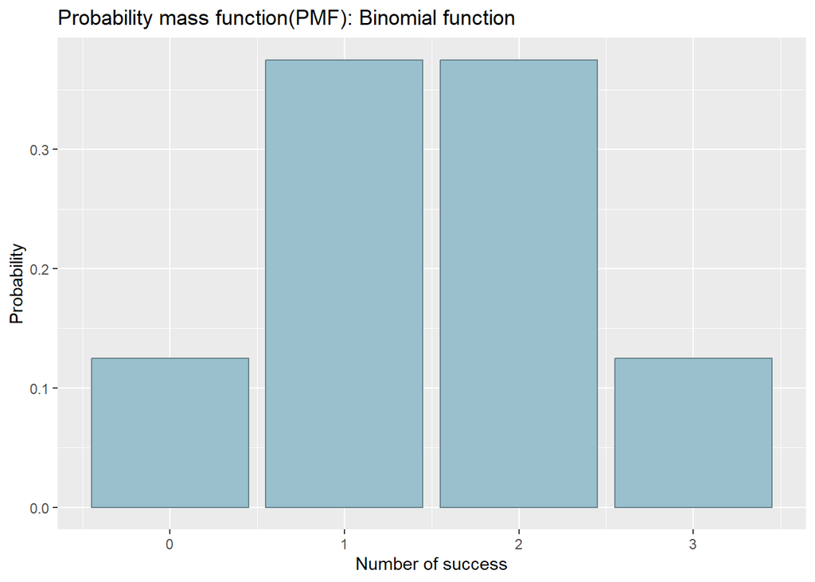

```r
y <- c(0, 1, 2, 3)
n <- 3
p <- 0.5
x <- dbinom(y, n, p)
df <- data.frame(y, x)
ggplot(df, aes(x = y, y = x))+
  geom_bar(stat = "identity", fill = "lightblue3", color = "lightblue4") +
  labs( title = "Probability mass function(PMF): Binomial function", x = "Number of success", y = "Probability")
```

**5. For (X) defined above, compute the expected value, variance, and standard deviation.**

**Solution:**

```r
ev <- sum(x*y)
print(paste("Expected value:", ev))
```

```
## [1] "Expected value: 1.5"
```

```r
varc <- p*(1-p)*n
print(paste("Variance:", varc))
```

```
## [1] "Variance: 0.75"
```

```r
print(paste("Standard deviation:", round(sqrt(varc), 2)))
```

```
## [1] "Standard deviation: 0.87"
```

**6. The height of individuals in a population follows a normal distribution with a mean of 170 cm and a standard deviation of 10 cm. Find the probability that a randomly chosen person is between 160 cm and 180 cm.**

**Solution:**

Given,

$\mu = 170cm$

$\sigma = 10cm$

```r
mu <- 170
sigma <- 10
prob_160 <- pnorm(160, mu, sigma)
prob_180 <- pnorm(180, mu, sigma)

prob_t = prob_180 - prob_160

print(paste("The probability that a randomly chosen person is between 160 cm and 180 cm is", round(prob_t, 2)))
```

```
## [1] "The probability that a randomly chosen person is between 160 cm and 180 cm is 0.68"
```

**7. Simulate 10,000 samples from the above normal distribution and compute the proportion of individuals between 160 and 180 cm. Compare it with the analytical result.**

**Solution:**

```r
n <- 10000
outcomes <- c()

sm <- rnorm(n, mu, sigma)
n_times <- sum(160 <= sm & sm <= 180)
prob_sm <- n_times/n
print(paste("Simulation proportion:", round(prob_sm,2)))
```

```
## [1] "Simulation proportion: 0.69"
```

```r
print(paste("Analytical result:", round(prob_t,2)))
```

```
## [1] "Analytical result: 0.68"
```

In summary, the simulation proportion and the analytical result are very close to each other.

**8. Given the joint probability mass function (PMF) of (X) and (Y) in the table below, compute the marginal PMFs of (X) and (Y).**

**Solution:**

**Joint probability mass function:**

```r
pmf_mt <- matrix(
  c(0.1, 0.2, 0.1, 0.15, 0.3, 0.15),
  nrow = 2, byrow = TRUE,
  dimnames = list(
    x <- c(0, 1),
    y <- c(0, 1, 2)
  )
)
```

```r
print(pmf_mt)
```

```
##      0   1    2
## 0 0.10 0.2 0.10
## 1 0.15 0.3 0.15
```

**With marginal values:**

```r
#For the marginal PMFs of (X) and (Y):

pmf_mt_m <- matrix(
  c(0.1, 0.2, 0.1, 0.4, 0.15, 0.3, 0.15, 0.6, 0.25, 0.5, 0.25, 1),
  nrow = 3, byrow = TRUE,
  dimnames = list(
    x <- c(0, 1, 'Mg'),
    y <- c(0, 1, 2, 'Mg')
  )
)
```

```r
print(pmf_mt_m)
```

```
##       0   1    2  Mg
## 0  0.10 0.2 0.10 0.4
## 1  0.15 0.3 0.15 0.6
## Mg 0.25 0.5 0.25 1.0
```

In the last column, we can see the marginal PMFs for (X):

$P_r(X = 0) = 0.4$ and $P_r(X = 1) = 0.6$.

For (Y), as indicated in the last row, the marginal PMFs are:

$P_r(Y = 0) = 0.25$, $P_r(Y = 1) = 0.5$ and $P_r(Y = 02) = 0.25$.

**9. Verify if the random variables (X) and (Y) from the table in Exercise 8 are statistically independent.**

**Solution:**

To verify independence we use:

$$P_r(X = x, Y = y) = P_r(X = x)P_r(Y =
y)$$

Hence, the variables X and Y are independents.

**10.1. Suppose you have a deck with only three cards. Each card has two sides, and each side is either black or white. One card has two black sides. The second card has one black and one white side. The third card has two white sides. Now suppose all three cards are placed in a bag and shuffled. Someone reaches into the bag and pulls out a card and places it flat on a table. A black side is shown facing up, but you don’t know the color of the side facing down. Show that the probability that the other side is also black is 2/3.**

**Solution:**

Let,

$A=$ The other side is black.

$B=$ The side facing up is black.

We want to determine the probability that the other side of the card is black, given that the side facing up is black. I.e. $P(A/B)$

Furthermore, any card can be chosen, so the probability to choosing each card is:

$C=$ Be chosen.

$P_r(C) = \frac{1}{3}$

Now, the probabilities of each card having the other side black, given the side facing up is black, corresponds to:

- Card Black/Black: $P_r(A/B) = 1$
- Card Black/White: $P_r(A/B) = 0.5$
- Card White/White: $P_r(A/B) = 0$

So, the probability of choosing any card and observing a black side corresponds to:

$$P_r(B) = \frac{1}{3}*1 + \frac{1}{3}*0.5
+ \frac{1}{3}*0 = \frac{1}{2}$$

Next, the probability of observing a black side and the other side also black only applies to the Black/Black card because, for the Black/White card, the other side can’t be black, and the last one is white for both side. So, The probability of observing a black side and having the other side is black is

$$P_r(B \cap A) = \frac{1}{3}*1 =
\frac{1}{3}$$

Finally,

$$P_r(A/B) = \frac{P_r(B \cap A)}{P_R(B)}
= \frac{\frac{1}{3}}{\frac{1}{2}}=\frac{2}{3}$$

**10.2. Now suppose there are four cards: B/B, B/W, W/W, and another B/B. Again suppose a card is drawn from the bag and a black side appears face up. Again calculate the probability that the other side is black.**

Let,

$A=$ The other side is black.

$B=$ The side facing up is black.

$C=$ Be chosen.

$P_r(C) = \frac{1}{4}$

We want to determine, $P(a/B)$

So, the probabilities of each card having the other side black, given the side facing up is black, corresponds to:

- Cards Black/Black: $P_r(A/B) = 1$
- Card Black/White: $P_r(A/B) = 0.5$
- Card White/White: $P_r(A/B) = 0$

Then,

$$P_r(B) = \frac{1}{2}*1 + \frac{1}{4}*0.5
+ \frac{1}{4}*0 = \frac{5}{8}$$

Furthermore, the probability of observing a black side and having the other side is black is

$$P_r(B \cap A) = \frac{1}{2}*1 =
\frac{1}{2}$$

Hence,

$$P_r(A/B) = \frac{P_r(B \cap A)}{P_R(B)}
= \frac{\frac{1}{2}}{\frac{5}{8}}=\frac{4}{5}$$

**11. Imagine that black ink is heavy,and so cards with black sides are heavier than cards with white sides. As a result, it’s less likely that a card with black sides is pulled from the bag. So again assume there are three cards: B/B, B/W, and W/W. After experimenting a number of times, you conclude that for every way to pull the B/B card from the bag, there are 2 ways to pull the B/W card and 3 ways to pull the W/W card. Again suppose that a card is pulled and a black side appears face up. Show that the probability the other side is black is now 0.5. Use the counting method, as before.**

**Solution:**

Given,

the weight for $B/B = 1$

the weight for $B/W = 2$

the weight for $W/W = 3$

Let,

$a: \#$ Of black sides in the card.

$b: \#$ Weight of the card.

Now, calculate the numbers of ways to observe the black side for each card: $a*b$

$B/B = 2 * 1 = 2$

$B/W = 1 * 2 = 2$

$B/B = 0 * 3 = 0$

So, the total number of ways to observe a black side is: $2 + 2 + 0 = 4 = N(B)$

To know the probability that the other side is black given that we observe a black side analyzing each card:

$B/B:$

This card satisfies the condition because if we see one black side, the other side is also black. Since $B/B$ contributes 2 ways to observe a black side, it satisfies the condition in 2 ways.

$B/W:$

This card has one black side and one white side. If the card is $B/W$, and we observe a black side, the other side must be white. Hence, this card not satisfy the condition.

$W/W:$

This card has no black sides, so we can’t see a black side. Thus, it doesn’t satisfy the condition.

Therefore, the only ways that satisfy the condition is with the $B/B$ card, which provides 2 forms. Finally, the probability corresponds to:

$A=$ The other side is black.

$B=$ The side facing up is black.

Since, $B/B$ satisfies the both condition, hence $P_r(A B) = $
$$P_r(A/B) =
\frac{N(A\cap B)}{N(B)} = \frac{\# ways (A \cap B)}{\#ways(black)} =
\frac{2}{4} = \frac{1}{2}$$

**12. Assume again the original card problem, with a single card showing a black side face up. Before looking at the other side, we draw another card from the bag and lay it face up on the table. The face that is shown on the new card is white. Show that the probability that the first card, the one showing a black side, has black on its other side is now 0.75. Use the counting method, if you can. Hint: Treat this like the sequence of globe tosses, counting all the ways to see each observation, for each possible first card.**

**Solution:**

Given,

$A=$ The other side is black.

$B=$ The side facing up is black.

$C=$ The other card facing up is white.

We want to determine $P(A/ B \cap C) = \frac{P(A\cap B\cap C)}{P(B\cap C)}$ Using the counting method: $P(A/ B \cap C) = \frac{N(A\cap B\cap C)}{N(B\cap C)}$

Considering $N(A \cap B \cap C)$, there are the following cases:

$B/B$ and $B/W:$

These cards satisfy the given conditions in two ways. The black side og the $B/B$ card with the white side of the $B/W$ card.

$B/B$ and $W/W:$

These cards also satisfy the given conditions in four ways. The black side of the $B/B$ card with any of side of the $W/W$ card and vice versa.

Thus, $N(A \cap B \cap C) = 4 + 2 = 6.$

Now, $N(B \cap C)$, there are these other cases:

$B/W$ and $W/W:$

These cards satisfy the conditions in two ways. The black side of the $B/W$ card with any sides of the $W/W$ card.

$B/B$ and $W/W:$

These cards also satisfy the given conditions in four ways. The black side of the $B/B$ card with any of side of the $W/W$ card and vice versa.

$B/B$ and $B/W:$ These cards satisfy the conditions $B$ and $C$ in another two ways. Either side of the $B/B$ card with the white side of the $B/W$ card.

So, $N(B \cap C) = 2 + 4 + 2 = 8.$

Hence,

$$P(A/ B \cap C) = \frac{N(A\cap B\cap
C)}{N(B\cap C)} = \frac{6}{8} = \frac{3}{4}$$

**13. Suppose there are two species of panda bear. Both are equally common in the wild and live in the same places. They look exactly alike and eat the same food, and there is yet no genetic assay capable of telling them apart. They differ however in their family sizes. Species A gives birth to twins 10% of the time, otherwise birthing a single infant. Species B births twins 20% of the time, otherwise birthing singleton infants. Assume these numbers are known with certainty, from many years of field research.**

**14. Now suppose you are managing a captive panda breeding program. You have a new female panda of unknown species, and she has just given birth to twins. What is the probability that her next birth will also be twins?**

**Solution:**

First, we want to determine the probability that the panda have birth to twins. So, considering that there are two types of species $S_a$ y $S_b$. Let’s use the law total probability where:

$A=$ Birth to twins

$S_a=$ Specie A

$S_b=$ Specie B

So,

$$P_r(A) =
P_r(A/S_a)P_r(S_a)+P_r(A/S_b)P_r(S_b)$$

$$P_r(A) = \frac{P_r(A\cap
S_a)}{P_r(S_a)}P_r(S_a)+\frac{P_r(A\cap
S_b)}{P_r(S_b)}P_r(S_b)$$

$$P_r(A) = P_r(A \cap S_a)+P_r(A\cap
S_b)$$

$$P_r(A) = 0.1 * 0.5 +0.2 * 0.5 =
0.15$$
Thus,

$P_r(A) = 0.15$

Now, for the probability that her next birth will also be twins when she already had twins, we use the Bayes theorem.

$$P_r(B/A) =
\frac{P_r(A/B)P_r(B)}{P_r(A)}$$

Now, we calculate the probability for specie A and B.

Specie A:

$$P_r(S_a/A) =
\frac{P_r(A/S_a)P_r(S_a)}{P_r(A)}$$
Thus,
$$P_r(S_a/A) = \frac{(0.1)(0.5)}{(0.15)} =
\frac{1}{3}$$

Specie B:

$$P_r(S_b/A) =
\frac{P_r(A/S_b)P_r(S_b)}{P_r(A)}$$

$$P_r(S_b/A) = \frac{(0.2)(0.5)}{0.15} =
\frac{2}{3}$$

Since we don’t know the birth specie, we can use law total probability:

Let,

$A:$ She already had birth to twins.

$B:$ She following birth is also to twins.

$$P_r(B/A) = P_r(B/S_a)P_r(S_a/A) +
P_r(B/S_b)P_r(S_b/A)$$
$$P_r(B/A) =
(0.1)(\frac{1}{3}) + (0.2)(\frac{2}{3}) = \frac{0.5}{3}$$

**15. Recall all the facts from the problem above. Now compute the probability that the panda we have is from species A, assuming we have observed only the first birth and that it was twins.**

**Solution:**

Considering the last problem:

Given,

$A:$ Birth to twins

$S_a:$ Being specie A

$$P_r(S_a/A) = \frac{(0.1)(0.5)}{(0.15)} =
\frac{1}{3}$$

**16. Continuing on from the previous problem, suppose the same panda mother has a second birth and that it is not twins, but a singleton infant. Compute the posterior probability that this panda is species A.**

Let,

$S_a:$ Panda’s mother is from specie A

$S_b:$ Panda’s mother is from specie B

$A:$ Panda baby is a singleton.

In first place consider, $P(A):$

$$P_r(A) = P_r(S_a/A)P_r(S_a) +
P_r(S_b/A)P_r(S_b)$$

$$P_r(A) = (0.9)(0.5) + (0.8)(0.5) \approx
\frac{17}{20} \approx 0.85$$

Then, by the Bayes theorem

$$P_r(S_a/A) =
\frac{P_r(A/S_r)P_r(S_a)}{P_r(A)}$$

$$P_r(A/S_a) = \frac{0.9*0.5}{0.85} =
\frac{0.45}{0.85}$$

**17. Suppose there is a blood test that correctly detects vampirism 95% of the time. In more precise and mathematical notation, Pr(positive test result|vampire) = 0.95. It’s a very accurate test, nearly always catching real vampires. It also make mistakes, though, in the form of false positives. One percent of the time, it incorrectly diagnoses normal people as vampires, Pr(positive test result|mortal) = 0.01. The final bit of information we are told is that vampires are rather rare, being only 0.1% of the population, implying Pr(vampire) = 0.001. Suppose now that someone tests positive for vampirism. What’s the probability that he or she is a bloodsucking immortal? Recreate this proportions and results in a population of 100.000 hab.through computational programs.**

**Solución:**

Let,

$A=$ Positive test result.

$B_1=$ Be vampire.

$B_2=$ Be mortal.

So, for the probability of the positive test result:

$$P_r(A) =
P_r(A/B_1)P_r(B_1)+P_r(A/B_2)P_r(B_2)$$

$$P_r(B/A) =
\frac{P_r(A/B)P_r(B)}{P_r(A)}$$

$$P_r(B/A) =
\frac{0.95*0.001}{0.01094}$$

$$P_r(B/A) = 0.087$$
Hence, $P_r(B/A) = 0.087$

For the proportions and results in a population of 100.000 hab:

```r
#Initial population
p_initial <- 100000

#probability positive test
t_vampire <- 0.001
t_mortal <- 1 - t_vampire

#Number of vampires or mortals
n_vampires <- p_initial*t_vampire
n_mortal <- p_initial*t_mortal

#Conditional probabilities:
#Being vampire and obtain a positive test
pos_vampire <- 0.95
#Not being vampire and obtain a positive test
pos_mortal <- 0.99

#Result cases: False positives and true negatives
t_positives <- pos_vampire * n_vampires
f_negatives <- (1 - pos_vampire) * n_vampires

f_positives <- (1 - pos_mortal) * n_mortal
t_negatives <- pos_mortal * n_mortal

#Total positives:
tot_positives <- t_positives + f_positives

#Probabilty of being a vampire given a positive test:
pr <- t_positives / tot_positives

print(paste("# Vampires corresponds to", n_vampires))
```

```
## [1] "# Vampires corresponds to 100"
```

```r
print(paste("# Mortals corresponds to", n_mortal))
```

```
## [1] "# Mortals corresponds to 99900"
```

```r
print(paste("# Real vampires", t_positives))
```

```
## [1] "# Real vampires 95"
```

```r
print(paste("# mortal detected like vampires", round(f_positives, 0)))
```

```
## [1] "# mortal detected like vampires 999"
```

```r
print(paste("# Total positives test", tot_positives))
```

```
## [1] "# Total positives test 1094"
```

```r
print(paste("Probabilty of being a vampire given a positive test", round(pr, 4)))
```

```
## [1] "Probabilty of being a vampire given a positive test 0.0868"
```

**18. Let $(X \sim Uniform(0,1))$. Define $(Y = X^{2})$. Simulate 10000 samples of $(X)$ and $(Y)$ and plot their joint distribution.**

Let,

$X \sim Uniform(0,1)$, $Y = X^2$:

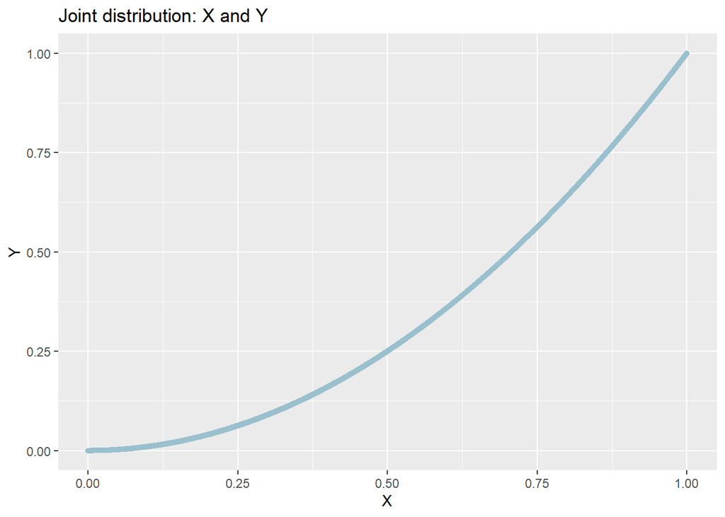

```r
set.seed(123)
n <- 10000
x <- runif(n, 0, 1)
y <- x^2

df <- data.frame(x, y)

ggplot(df, aes(x = x, y = y)) +
  geom_point(color = "lightblue3")+
  labs(title = "Joint distribution: X and Y",
       x = "X", y = "Y")
```

**19. For the same $(X)$ and $(Y)$, compute the expected value of $(Y)$ and compare it with the theoretical result.**

Let,

**20. A company manufactures two products, A and B. The probabilities of defects are 0.05 and 0.1, respectively. Product A represents 70% of the production, and Product B represents 30%. If a randomly selected product is defective, what is the probability it is Product B?**

**Solution:**

Let,

$A_1=$ Product A.

$A_1=$ Product B.

$B=$ Being defective.

For $P_r(B) = P_r(B/A_1)P_r(A_1) + P_r(B/A_2)P_r(A_2)$

$$P_r(B) = 0.05*0.7 + 0.1*0.3 =
0.065$$
Then, using the Bayes theorem,

$$P_r(A_2/B) =
\frac{P_r(A_2/B)P_r(A_2)}{P_r(B)}$$

$$P_r(A_2/B) =
\frac{(0.1)(0.3)}{0.065}$$

$$P_r(A_2/B) = \frac{6}{13} \approx
0.46$$

Hence, the probability of being product B given that it is defective is $P_r(A_2/B) \approx 0.46.$